# STA-380-Homework-1-Dalton-Haines-Jansen-Karnes

Contributors: Reed Dalton, Corey Haines, Alex Jansen, McKenna Karnes

# Probability Practice

### Part A.

Given a single survey question to visitors to a particular website, what fraction of people who truthfully answered the question answered yes?  
* There are two types of clickers: Random Clickers (RC), and Truthful Clickers (TC)  
* There are two answers to the survey: yes and no  
* The expected fraction of Random Clickers (RC) is 0.3  
* The expected fraction of Truthful Clickers (TC) is 0.7  
* The probability that the Random Clickers (RC) selects yes is .5  
* The probability that the Random Clickers (RC) selects no is .5  
The results of the survey were such that 65% said Yes and 35% said No.

```r
prob.yes = 0.65
prob.no = 0.35
prob.yes.given.RC = 0.5
prob.no.given.RC = 0.5
prob.TC = 0.7
prob.RC = 0.3
prob.yes.given.TC = (prob.yes - (prob.RC * prob.yes.given.RC))/prob.TC
```

`prob.yes` = `prob.TC` * `prob.yes.given.TC` + `prob.RC` * `prob.yes.given.RC`

The percentage of Truthful Clickers who answered “Yes” to the the simple survey is 0.7142857

### Part B.

Medical test for disease using Bayes Formula.  
* The sensitivity is about 0.993. That is, if someone has the disease, there is a probability of 0.993 that they will test positive.  
* The specificity is about 0.9999. This means that if someone doesn’t have the disease, there is probability of 0.9999 that they will test negative.  
* About 0.0025% of all people in the general population have the disease If someone tests positive for the disease, what is the probability they actually have the disease?

```r
pop.infected = 0.000025
pop.clean = 0.999975

infected.pos = 0.993
infected.neg = 0.007

clean.pos = 0.0001
clean.neg = 0.9999
infected.test.pos = (infected.pos*pop.infected)/(infected.pos*pop.infected + clean.pos*pop.clean)
infected.test.pos = infected.test.pos * 100
```

If someone tested positive for the disease, there is only a 19.8882413% chance that they actually have the disease.

Given our calculations, implementing a universal testing policy for this disease would be problematic because over 80% of the time a test for the disease is positive, the person will not actually be infected. This could lead to mass hysteria and put unneeded strain on the population’s health systems.

# Exploratory Analysis: Green Buildings

- The baseline construction costs are $100 million, with a 5% expected premium for green certification.

```r
#setwd('/Users/Reeddalton/Documents/GitHub/STA-380-Homework-1-Dalton-Haines-Jansen-Karnes')
GreenBuildings = read.csv('greenbuildings.csv')
```

# Bootstrapping and ETF Returns

- To understand the tradeoffs of risk and return of Exchange Traded Funds, we explored the growth over several years of historical data of the following ETFs:
  - US domestic equities (SPY: the S&P 500 stock index)
  - US Treasury bonds (TLT)
  - Investment-grade corporate bonds (LQD)
  - Emerging-market equities (EEM)
  - Real estate (VNQ)
- Given a notional $100,000 to invest, we considered three portfolios with varying levels of risk:
  - Even Split: 20% of assets in each of the five ETFs
  - Safer Split: investments assets in at least three classes
  - Aggresive Split: consolidating assets into fewer classes with the promise of higher returns at the cost of accepting greater risk
- We have assumed the portfolio is rebalanced for free each day i.e. rebalanced with zero transaction costs

```r
#Import the stocks
mystocks = c("SPY", "TLT", "LQD", "EEM", "VNQ")
getSymbols(mystocks)
```

```
## [1] "SPY" "TLT" "LQD" "EEM" "VNQ"
```

```r
#Adjust for splits and dividends
SPYa = adjustOHLC(SPY)
TLTa = adjustOHLC(TLT)
LQDa = adjustOHLC(LQD)
EEMa = adjustOHLC(EEM)
VNQa = adjustOHLC(VNQ)
```

- First we imported the last 10 years of prices of the 5 ETFs from Yahoo Finance’s database. We made sure to account for any splits or dividends in the ETFs over that time.

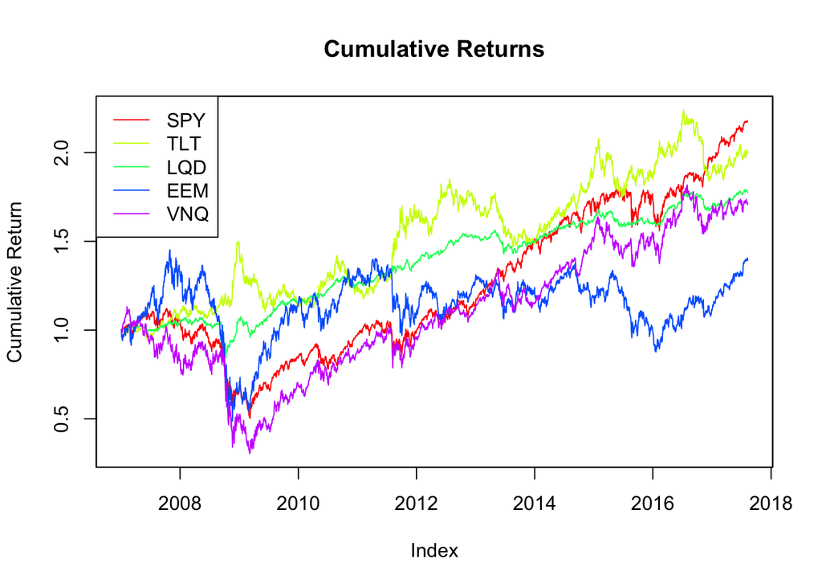

```r
SPYa.adj <- SPYa[,6]
TLTa.adj <- TLTa[,6]
LQDa.adj <- LQDa[,6]
EEMa.adj <- EEMa[,6]
VNQa.adj <- VNQa[,6]

SPYa1 = as.numeric(SPYa.adj[1])
TLTa1 = as.numeric(TLTa.adj[1])
LQDa1 = as.numeric(LQDa.adj[1])
EEMa1 = as.numeric(EEMa.adj[1])
VNQa1 = as.numeric(VNQa.adj[1])

SPYa.ts =SPYa.adj/SPYa1
TLTa.ts =TLTa.adj/TLTa1
LQDa.ts =LQDa.adj/LQDa1
EEMa.ts =EEMa.adj/EEMa1
VNQa.ts =VNQa.adj/VNQa1

basket <- cbind(SPYa.ts,TLTa.ts,LQDa.ts,EEMa.ts,VNQa.ts  )
zoo.basket <- as.zoo(basket)
tsRainbow <- rainbow(ncol(zoo.basket))
plot(x = zoo.basket, ylab = "Cumulative Return", main = "Cumulative Returns",col = tsRainbow, screens = 1)
legend(x = "topleft", legend = c("SPY", "TLT", "LQD", "EEM", "VNQ"), lty = 1,col = tsRainbow)
```

* Next we plotted the Cumulative Returns of each stock from 2007 to 2017-08-09.  
+ This allowed us to visualize each ETF’s gains/loses over time.  
+ Visually, it seems that LQD has less volatility than EEM.  
+ Rather than looking at this graph, we would like a way to standardize our comparison of the risk for investing in each ETF.  
+ We believe value at risk (VaR) will be a good comparison measure.

### Even Split Portfolio

```r
#############################
#########Even Split Portfolio
#############################

#Setting up an all returns matrix showing closing prices for each day
all_returns = cbind(ClCl(SPYa),ClCl(TLTa),ClCl(LQDa), ClCl(EEMa), ClCl(VNQa))
all_returns = as.matrix(na.omit(all_returns))

n_days = 20#i.e. four weeks

#Setting up the Even Split Portfolio and using Bootstrap to find VaR
initial.wealth = 100000
sim.even = foreach(i=1:5000, .combine = 'rbind')%do%{
  days = 20
  total.wealth = initial.wealth
  even.weight = c(0.2,0.2,0.2,0.2,0.2)
  even.holdings = even.weight*total.wealth
  even.wealthtracker = rep(0,days)
  #loop over four trading weeks
  for(today in 1:days){
    return.today = resample(all_returns, 1, orig.ids = FALSE)
    even.holdings = even.holdings + even.holdings*return.today
    total.wealth = sum(even.holdings)
    even.wealthtracker[today] = total.wealth
  }
  even.wealthtracker
}

#Calculate 5% VaR for even portfolio
even.split.VaR = quantile(sim.even[,n_days], 0.05) - initial.wealth
```

For our Even Split portfolio, we placed $20,000 in each of the 5 ETFs.

Even Split:  
* At the five percent level, The value at risk for our even split portfolio is -6173.7722465.

### Safer Split

```r
##################
###### Safer Split
##################

safe_returns = cbind(ClCl(SPYa),ClCl(TLTa),ClCl(LQDa))
safe_returns = as.matrix(na.omit(safe_returns))

#Setting up the Safe Split Portfolio and using Bootstrap to find VaR

initial.wealth = 100000

sim.safe = foreach(i=1:5000, .combine = 'rbind')%do%{
  days = 20
  total.wealth = initial.wealth
  safe.weight = c(1/3,1/3,1/3)
  safe.holdings = safe.weight*total.wealth
  safe.wealthtracker = rep(0,days)
  #loop over four trading weeks
  for(today in 1:days){
    return.today = resample(safe_returns, 1, orig.ids = FALSE)
    safe.holdings = safe.holdings + safe.holdings*return.today
    total.wealth = sum(safe.holdings)
    safe.wealthtracker[today] = total.wealth
  }
  safe.wealthtracker
}

#Calculate 5% VaR for safe portfolio
safe.split.VaR = quantile(sim.safe[,n_days], 0.05) - initial.wealth
```

For the Safe Split, we limited our portfolio to only 3 ETFs made up of the S&P, Treasury Bonds, and Corporate Bonds. Treasury Bonds are a safe investment because they are guaranteed by the Federal Government and are virtually risk free. Corporate Bonds are a safe investment because they will pay out unless the company defaults. And the S&P is a good sample of how the entire stock market functions, and is diversified enough to not be too influenced by sector fluctuations.

### Aggressive Portfolio

```r
########################
####Aggressive Portfolio
########################
aggressive_returns = cbind(ClCl(EEMa),ClCl(VNQa))
aggressive_returns = as.matrix(na.omit(aggressive_returns))

#Setting up the Agressive Split Portfolio and using Bootstrap to find VaR

initial.wealth = 100000

sim.aggressive = foreach(i=1:5000, .combine = 'rbind')%do%{
  days = 20
  total.wealth = initial.wealth
  aggressive.weight = c(1/2,1/2)
  aggressive.holdings = aggressive.weight*total.wealth
  aggressive.wealthtracker = rep(0,days)
  #loop over four trading weeks
  for(today in 1:days){
    return.today = resample(aggressive_returns, 1, orig.ids = FALSE)
    aggressive.holdings = aggressive.holdings + aggressive.holdings*return.today
    total.wealth = sum(aggressive.holdings)
    aggressive.wealthtracker[today] = total.wealth
  }
  aggressive.wealthtracker
}

#Calculate 5% VaR for aggressive portfolio
aggressive.split.VaR = quantile(sim.aggressive[,n_days], 0.05) - initial.wealth
```

For the Aggresive Split, we shrunk our portfolio to only 2 ETFs made up of Real Estate and Emerging Market Equities. Real Estate is a risky investment as one could see from the 2008 housing bubble and the forclosures caused by the sub-prime mortgage crisis, but can grow quickly based on speculation. Emerging Market Equities have a high chance of failing due to geopolitics and various other factors, but there are high growth oppurtunities.

# NutrientH2O Market Segmentation

```r
social_marketing = read.csv('social_marketing.csv')
smm = social_marketing[ , -which(names(social_marketing) %in% c("chatter","spam", 'uncategorized'))]
sm <- smm[,-1]/rowSums(smm[,-1], na.rm = FALSE)
sm_scaled <- scale(sm, center=TRUE, scale=TRUE)
```

### Pre-Proccessing

- To start, we found the proportion of each follower’s tweets per category over their total tweets.
- Next, we determined there was likely no realistic way to use `chatter` and `uncategorized` to find interesting insight into NutrientH2O’s followers other than their propensity for twitter. Because we scaled by the total number of tweets, we chose to drop these catagories.
- Following the previous point, it did not seem like a feasible idea to create a marketing campaign based off of spam tweets.
- No account tweets out more than 2 tweets categorized as `spam`, and the highest percentage of an account’s tweets being categorized as `spam` was 7%, for the simplicity of the model we chose to drop the category anyways.
- While it is probably not a strong idea for NutrientH2O to make a marketing campaign based on adult themes, we felt that leaving the `adult` category in the data made sense because it captured some demographic information about NutrientH2O followers.
- Although potentially redundant, we chose to also center and scale our data to ensure that our kmean centers would be interpretable.

### Determining ‘K’

To try and determine the optimal K-number of clusters to group the categories of tweets by NutrientH2O follower, we first expirmented with finding the number of clusters with the highest CH(k) score when running kmeans++. From the graph, the highest score came when the data was grouped into 3 clusters.

```r
ch.index = function(x,kmax,iter.max=100,nstart=10,algorithm="Lloyd") {
  ch = numeric(length=kmax-1)
    n = nrow(x)
    for (k in 2:kmax) {
        a = kmeanspp(x,k,iter.max=iter.max,nstart=nstart,algorithm=algorithm)
        w = a$tot.withinss
        b = a$betweenss
        ch[k-1] = (b/(k-1))/(w/(n-k))
        }
    return(list(k=2:kmax,ch=ch))
}
```

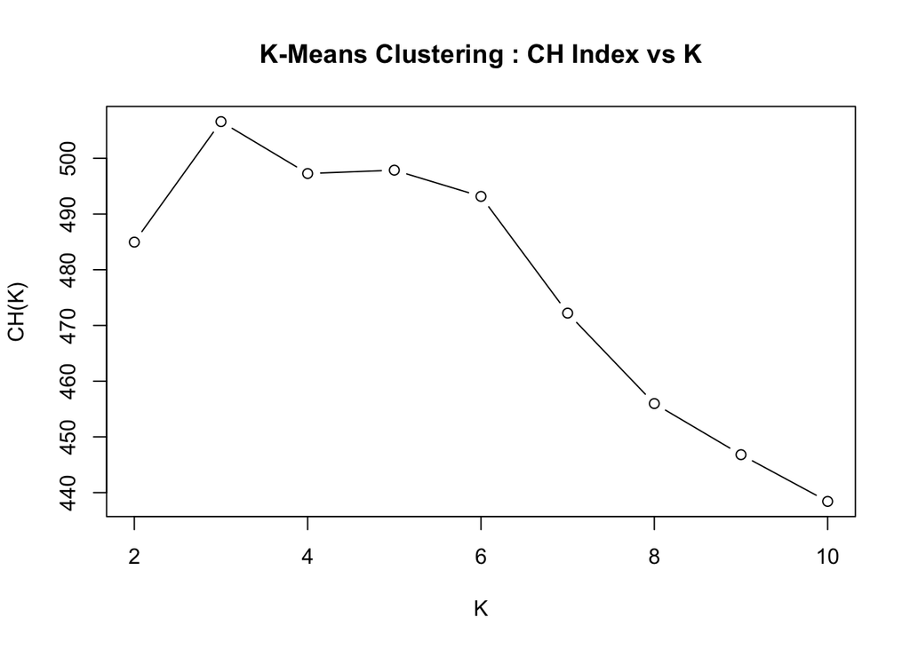

```r
a1 = ch.index(sm_scaled, 10)
k1.hat = a1$k[which.max(a1$ch)]
plot(a1$k,a1$ch, xlab='K', ylab='CH(K)', type='b', main='K-Means Clustering : CH Index vs K' )
```

We then ran Kmeans++, as Kmeans++ has a higher chance of optimizing the objective function and finding the most optimal clustering than normal Kmeans clustering.

```r
maxCH = kmeanspp(sm_scaled, 3,iter.max=100,nstart=10,algorithm="Lloyd")
```

### Finding Insights

In order to develop insights, we examine the distance of each category from the center in each of the cluster. We sorted based on distance and created barcharts for each of the clusters.

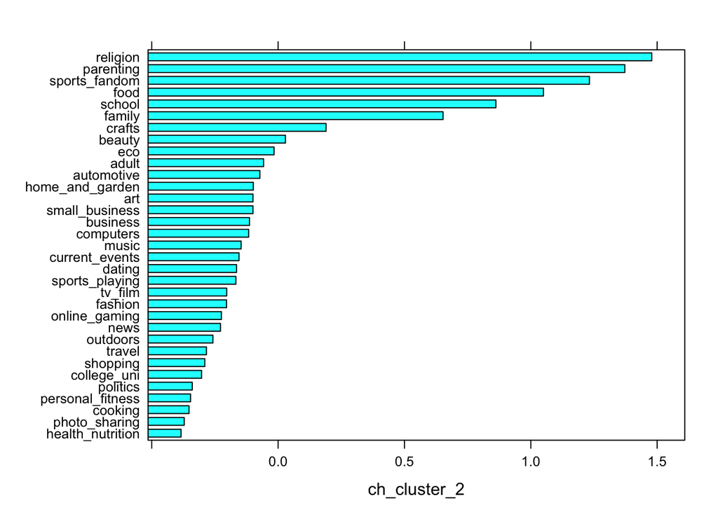

```r
ch_cluster_1 = sort(maxCH$centers[1,])
ch_cluster_2 = sort(maxCH$centers[2,])
ch_cluster_3 = sort(maxCH$centers[3,])
par(mfrow=c(1,3))
barchart(ch_cluster_2)
```

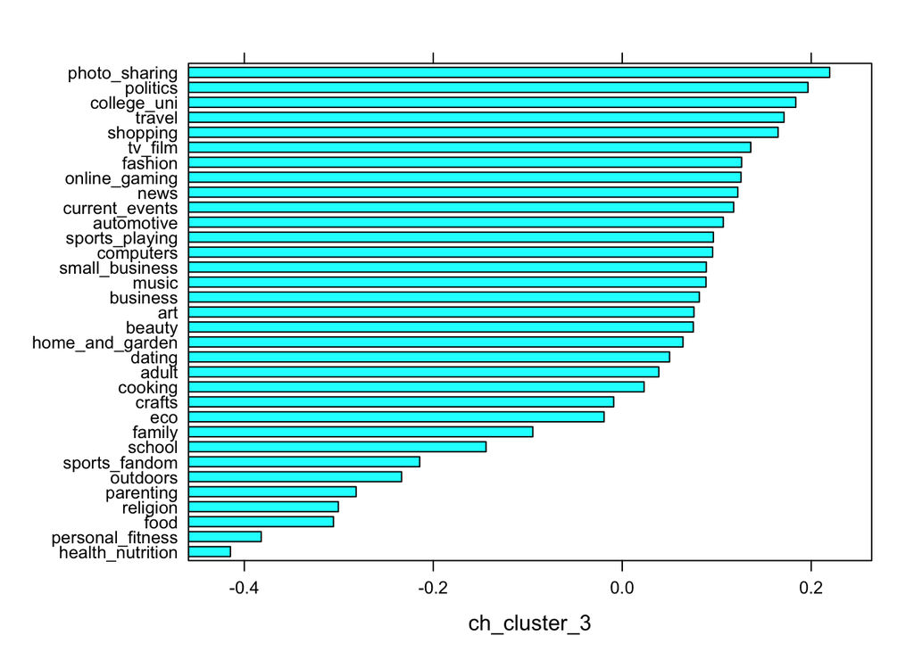

```r
barchart(ch_cluster_3)
```

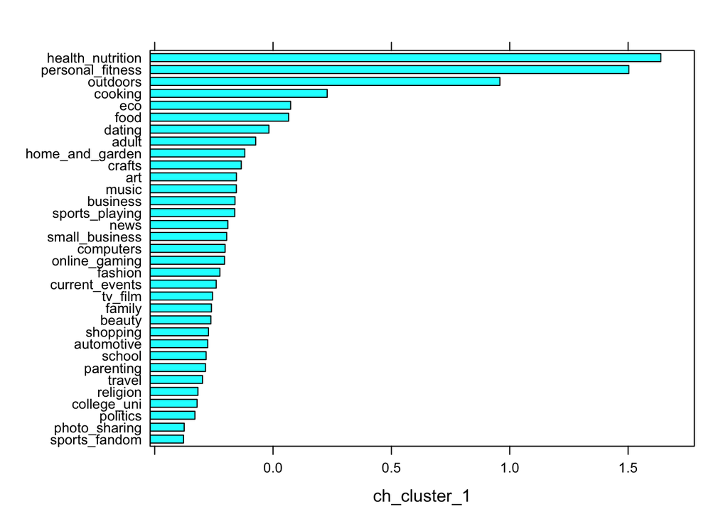

```r
barchart(ch_cluster_1)
```

### Elbow Method

We continued our exploration for the optimal number of cluster with the implementaiton of the Elbow Method. The Elbow Method requires running kmeans or kmeans++ on multiple k number of clusters and plotting them based on the sum of squared errors (SSE). A visual inspection is performed on the line chart. If there is a noticable inflection point in the line, i.e. at the Elbow, the inflection point is the ideal number of clusters for Kmeans.

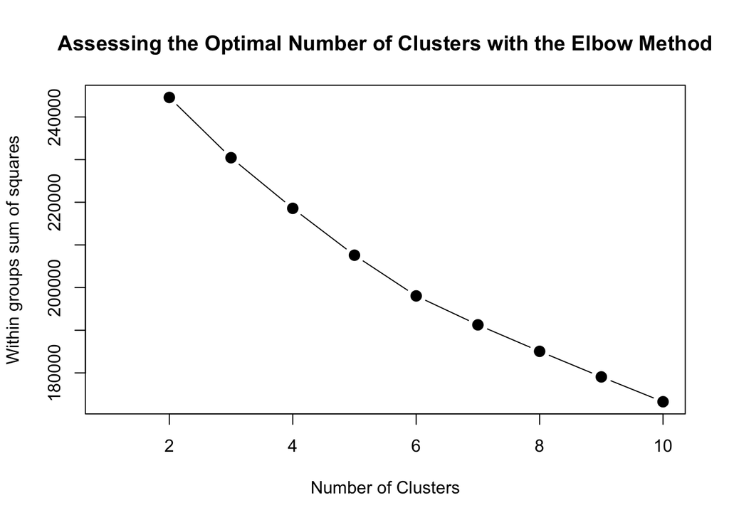

```r
wss <- matrix(,nrow = length(2:10), ncol = 1);

  for (i in 2:10) wss[i] <- sum(kmeanspp(sm_scaled,i,iter.max=100,nstart=10,algorithm="Lloyd")$withinss)

plot(1:10, wss, type="b", xlab="Number of Clusters",
     ylab="Within groups sum of squares",
     main="Assessing the Optimal Number of Clusters with the Elbow Method",
     pch=20, cex=2)
```

From the graph, there appears ever so slightly to be an inflection point at 6 clusters.

```r
maxElbow = kmeanspp(sm_scaled, 6,iter.max=100,nstart=10,algorithm="Lloyd")
```

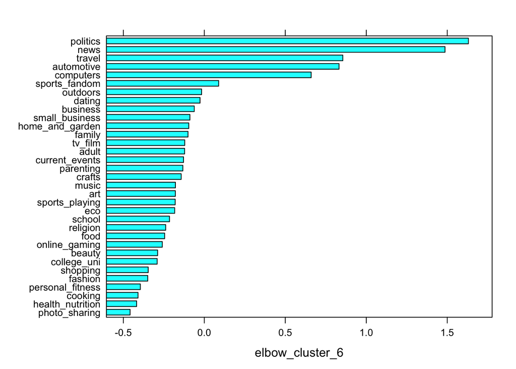

```r
elbow_cluster_1 = sort(maxElbow$centers[1,])
elbow_cluster_2 = sort(maxElbow$centers[2,])
elbow_cluster_3 = sort(maxElbow$centers[3,])
elbow_cluster_4 = sort(maxElbow$centers[4,])
elbow_cluster_5 = sort(maxElbow$centers[5,])
elbow_cluster_6 = sort(maxElbow$centers[6,])
par(mfrow=c(3,2))
#Clusters plotted in order of decreasing withinss
barchart(elbow_cluster_6)
```

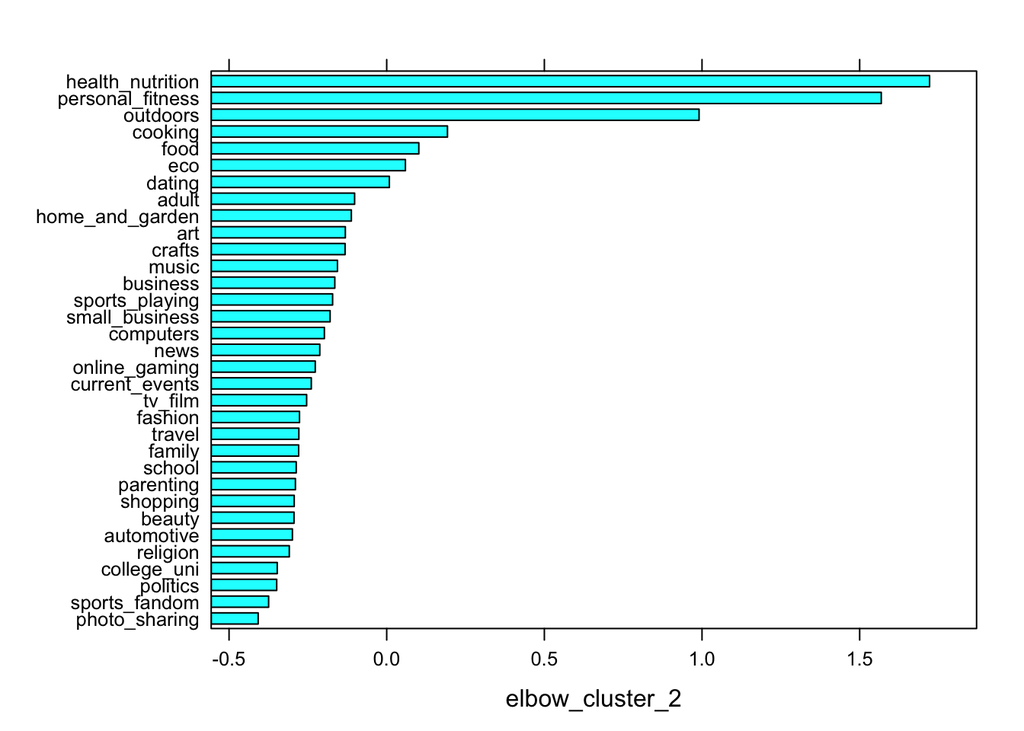

```r
barchart(elbow_cluster_2)
```

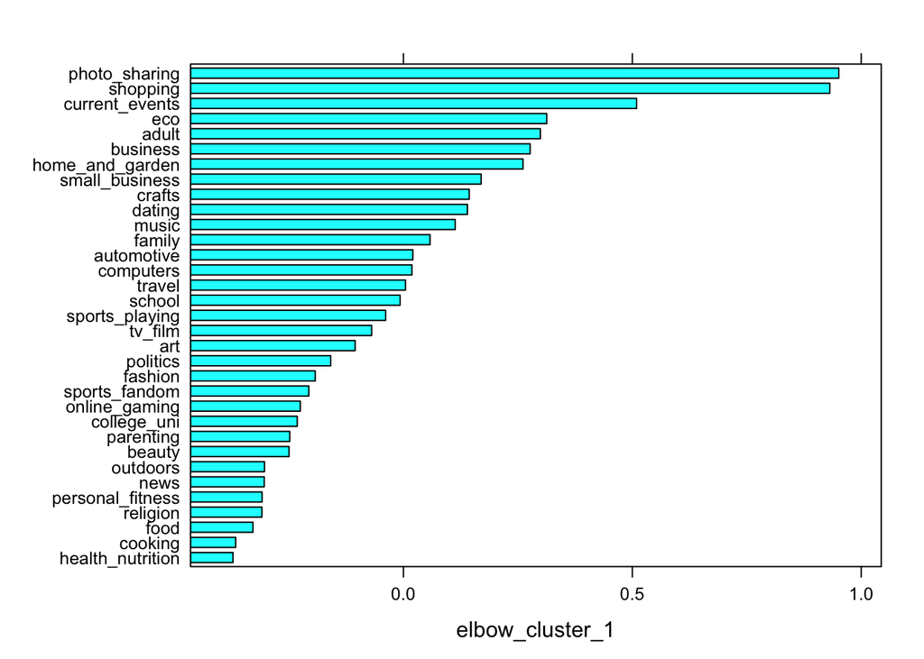

```r
barchart(elbow_cluster_1)
```

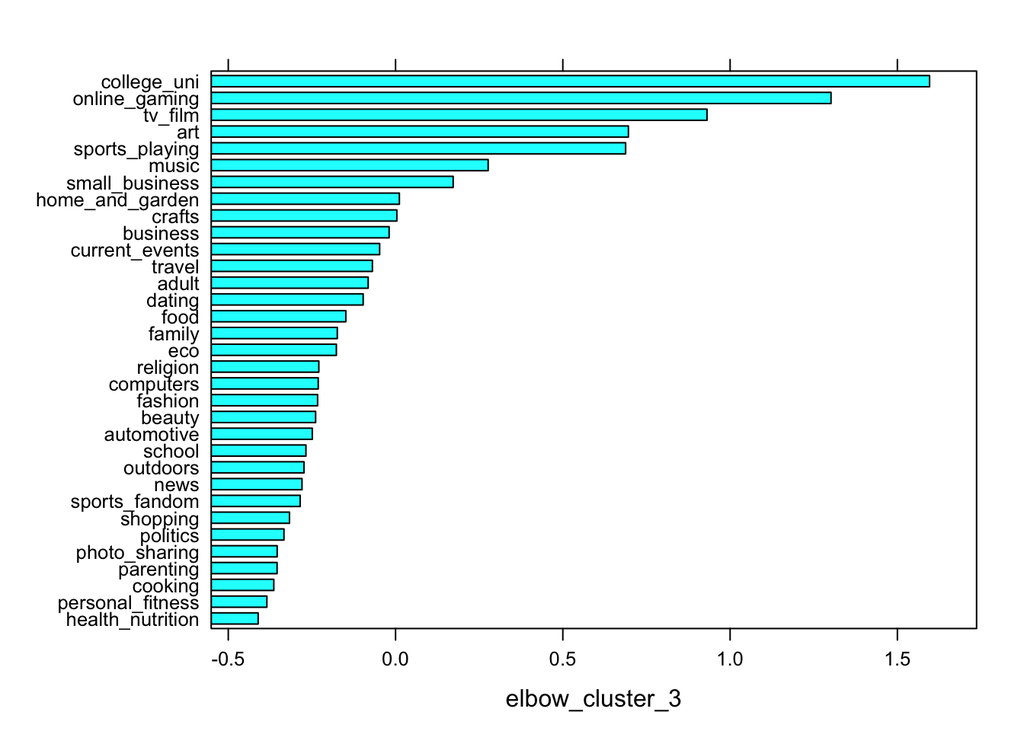

```r
barchart(elbow_cluster_3)
```

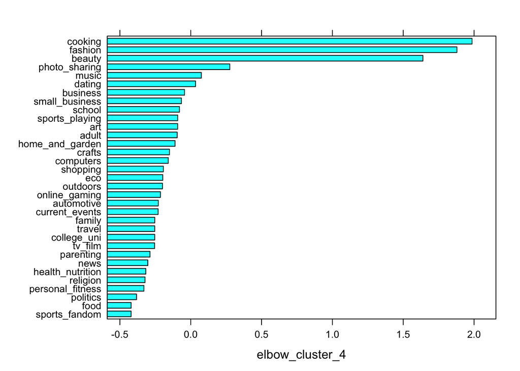

```r
barchart(elbow_cluster_4)
```

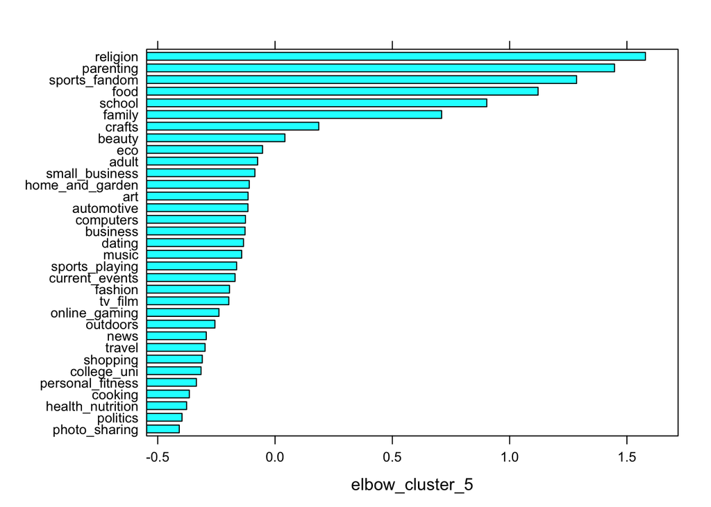

```r
barchart(elbow_cluster_5)
```